# Final Project

Sujay Banerjee and Olivia Chen

2022-12-12

#### MATH 0116 Final Project

#### Professor Alex Lyford

##### “We have neither given nor received unauthorized aid on this assignment”

### **Introduction**

[output not shown]

```r
library(tidyverse)
library(ggpubr)
library(rstatix)
friends <- read.csv("/Users/suj/Downloads/Copy of Social Satisfaction Survey (Responses) - Form Responses 1.csv")
friend_2 <- read.csv("/Users/suj/Downloads/FriendGroupData.csv")
```

```r
friendGroup <- friends %>%
  pivot_longer(-ID,
               names_to = "Year",
               values_to = "Satisfaction")
```

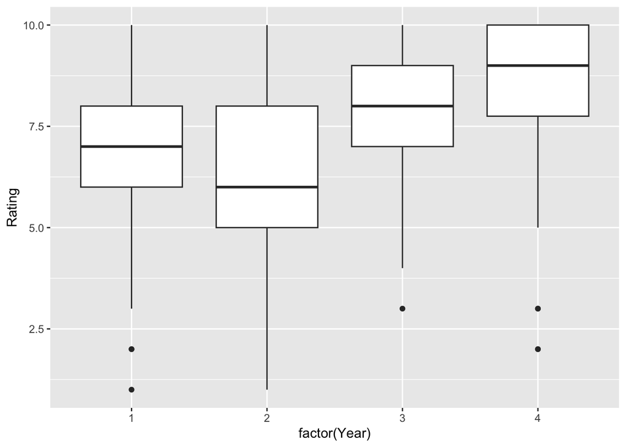

```r
library(dplyr)
library(ggplot2)

ggplot(friend_2) +
  geom_boxplot(aes(x = factor(Year), y = Rating))
```

```r
#Box plots showing the distribution of social satisfaction ratings over the years
```

### **Methods**

[output not shown]

```r
#Assumptions

#1) Data are collected with randomization and independence
```

[output not shown]

```r
#2) Check for  significant outliers
identify_outliers(Satisfaction, data = friendGroup)
```

```
## # A tibble: 2 × 5
##      ID Year      Satisfaction is.outlier is.extreme
##   <int> <chr>            <int> <lgl>      <lgl>
## 1     1 Sophomore            1 TRUE       FALSE
## 2    34 Freshman             1 TRUE       FALSE
```

[output not shown]

```r
#3) Check for normality
friendGroup %>%
  group_by(Year) %>%
  shapiro_test(Satisfaction)
```

```
## # A tibble: 4 × 4
##   Year      variable     statistic           p
##   <chr>     <chr>            <dbl>       <dbl>
## 1 Freshman  Satisfaction     0.924 0.00654
## 2 Junior    Satisfaction     0.913 0.00279
## 3 Senior    Satisfaction     0.758 0.000000403
## 4 Sophomore Satisfaction     0.962 0.160
```

```
The next assumption is normality: we determined with a Shapiro-Wilkes test that only our data for sophomore year is normally distributed. However, we decided to proceed anyway because we have a large enough sample size.
```

```r
# 4) Check for sphericity
```

[output not shown]

### **Results**

[output not shown]

```r
library(rstatix)

g <- aov(Satisfaction ~ Year + Error(ID), data = friendGroup)
summary(g)
```

```
##
## Error: ID
##           Df Sum Sq Mean Sq F value Pr(>F)
## Residuals  1 0.9827  0.9827
##
## Error: Within
##            Df Sum Sq Mean Sq F value   Pr(>F)
## Year        3  106.4   35.45   7.845 6.18e-05 ***
## Residuals 171  772.8    4.52
## ---
## Signif. codes:  0 '***' 0.001 '**' 0.01 '*' 0.05 '.' 0.1 ' ' 1
```

Looking at all the other matched-pairs t-tests, the only combinations of years in which we failed to reject the null hypothesis of 0 change in social satisfaction ratings was between freshman and sophomore year and junior and senior year. The p-value for the t-test comparing freshman and sophomore years is 0.3656, meaning that we fail to reject the null hypothesis of there being no difference between these two years. Also, looking at the 95% confidence interval for freshman and sophomore year, 0 is contained within the range, which means that is plausible for their to be no mean difference. There was a significant difference in social satisfaction between freshman and junior year (p-value = 0.0154). 0 is not contained within the 95% confidence interval, meaning that it is not plausible for their to be no mean difference in social satisfaction. There was a very significant difference in social satisfaction between freshman and senior year (p-value = 0.0008). The 95% confidence interval does not contain 0, so we can reject the null hypothesis that there is no change in social satisfaction. Looking at sophomore and junior year, there is also a significant difference in social satisfaction (p-value = 0.0006). There is the most significant difference between sophomore and senior year (p-value = 8.417x10-5). Finally, between junior and senior year, there is no significant difference in social satisfaction (p-value = 0.1949). The 95% confidence interval contains 0, indicating that it is plausible that there is no change in social satisfaction.

```r
#Other year comparisons
t.test(friends$Freshman, friends$Sophomore, paired = TRUE)
```

```
##
##  Paired t-test
##
## data:  friends$Freshman and friends$Sophomore
## t = 0.91447, df = 43, p-value = 0.3656
## alternative hypothesis: true mean difference is not equal to 0
## 95 percent confidence interval:
##  -0.4930829  1.3112647
## sample estimates:
## mean difference
##       0.4090909
```

```r
t.test(friends$Freshman, friends$Junior, paired = TRUE)
```

```
##
##  Paired t-test
##
## data:  friends$Freshman and friends$Junior
## t = -2.5233, df = 43, p-value = 0.0154
## alternative hypothesis: true mean difference is not equal to 0
## 95 percent confidence interval:
##  -1.9627907 -0.2190275
## sample estimates:
## mean difference
##       -1.090909
```

```r
t.test(friends$Freshman, friends$Senior, paired = TRUE)
```

```
##
##  Paired t-test
##
## data:  friends$Freshman and friends$Senior
## t = -3.5971, df = 43, p-value = 0.0008251
## alternative hypothesis: true mean difference is not equal to 0
## 95 percent confidence interval:
##  -2.3409632 -0.6590368
## sample estimates:
## mean difference
##            -1.5
```

```r
t.test(friends$Sophomore, friends$Junior, paired = TRUE)
```

```
##
##  Paired t-test
##
## data:  friends$Sophomore and friends$Junior
## t = -3.7117, df = 43, p-value = 0.0005873
## alternative hypothesis: true mean difference is not equal to 0
## 95 percent confidence interval:
##  -2.3150013 -0.6849987
## sample estimates:
## mean difference
##            -1.5
```

```r
t.test(friends$Sophomore, friends$Senior, paired = TRUE)
```

```
##
##  Paired t-test
##
## data:  friends$Sophomore and friends$Senior
## t = -4.3427, df = 43, p-value = 8.417e-05
## alternative hypothesis: true mean difference is not equal to 0
## 95 percent confidence interval:
##  -2.795642 -1.022540
## sample estimates:
## mean difference
##       -1.909091
```

```r
t.test(friends$Junior, friends$Senior, paired = TRUE)
```

```
##
##  Paired t-test
##
## data:  friends$Junior and friends$Senior
## t = -1.3167, df = 43, p-value = 0.1949
## alternative hypothesis: true mean difference is not equal to 0
## 95 percent confidence interval:
##  -1.0356654  0.2174835
## sample estimates:
## mean difference
##      -0.4090909
```

### **Conclusion**

[output not shown]

[output not shown]